```python
import pandas as pd
from matplotlib import pyplot as plt
```

# Feature Engineering

This dataset required a lot of feature engineering.  
The features of the original dataset were things like 'current x fixation', 'current y fixation', 'saccade length', and 'saccade angle': features describing the coordinates of the eye fixation. This information is helpful, but certainly nothing that you could feed into a learning algorithm and hope to get meaningful results from.  
First, we must ask 'Are eye fixations a good measure of visual attention? Is it both necessary and sufficient to fixate the eye on a location in order to attend to it?' This is a very interesting question. The answer is that we're not completely sure, but it has been found to be the best proxy for attention [1]. Alternatively, we could maybe hook up an electroencephalogram to the patient, but even then, modern science is not entirely sure what the brain mechanisms are that correspond to visual attention [2]. Thus, we will assume that eye fixations are necessary and sufficient conditions for visual attention for the remainder of this project. For my features, I looked at low-level features of the image in a neighborhood near the eye fixation. I let this neighborhood be a ball of radius 75 pixels, which corresponds pretty well to how much peripheral vision you have when you are focusing on a single point.  
Thus, I had a lot of images that looked something like this, where the red ball is centered at the human eye fixation:

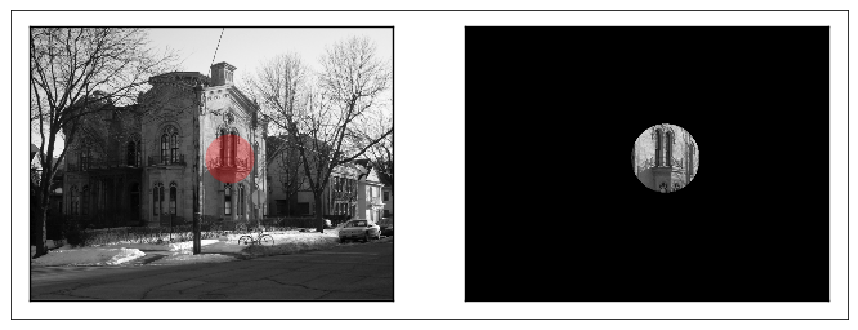

```python
img = plt.imread('cutout.png')
plt.figure(figsize=(15,15))
m,n,k = img.shape
plt.imshow(img)
plt.xticks([])
plt.yticks([])
plt.ylim([420,180])
plt.xlim([85,735])
plt.show()
```

Now, deciding where to look in a scene requires a very high-level understanding of the scene. For example, in the above image, bicycles and cars are more interesting than piles of snow and roads. However, there is no 'bicycle' feature that I could extract from this image. Well, there is, but it requires many layers of a deep neural network to extract [3]. The whole point of this project is to develop some model of human visual attention (which generally relies on high-level understanding) using low-level features of the image.  
Thus, my hypothesis is that some combination of low-level data will correlate with visual attention strongly enough that we can predict eye fixations on a novel image.  
The features that I chose to extract from the localized image are:

1. Picture name
2. X center (of localization)
3. Y center (of localization
4. Brightness (calculated by the mean value of the V channel in a HSV image).
5. Contrast (RMS).
6. Focus measure - basically 'how blurry the image is' - (calculated by the variance of the Laplacian transform [4]).
7. RMS contrast on the vertical edges (Sobel X edge detector)
8. Focus measure on the vertical edges (Sobel X edge detector)
9. RMS contrast on the horizontal edges (Sobel Y edge detector)
10. Focus measure on the horizontal edges (Sobel Y edge detector)
11. Indoor/outdoor

I iterated through every 5 pixels (i.e., 0,5,10,...,800) of each of the 32 images, and gathered these 11 features at each point. The 'label' of the data will be EYE FIXATION: Y/N. I anticipate that using this information, we will be able to accurately predict the eye fixations of a person given a novel image.  
If we can manage that, then we'll have a good way of modeling high-level visual decisions using low-level image features. That would be exciting. I will continue to search for other low-level properties of images to feed into my model, but for now, these are the ones that I have. Notice that the 11th feature, indoor/outdoor, is a high-level property of the image, and will be hand-labeled. This is, of course, cheating, but it is a very easy label, and should be knowable information in real-world applications. In the table below, the image is of a butcher shop, so it is indoors, so the 'Outdoor' boolean variable is False, corresponding to a 0.

Here is an example of one of the CSVs corresponding to one of the 32 images:

```python
df = pd.read_csv('butchers_shop.csv', index_col=False)
df.head()
```

|  | Picture | X_center | Y_center | Brightness | Contrast | FM | VerticalContrast | VerticalFM | HorizontalContrast | HorizontalFM | Outdoor |
| --- | --- | --- | --- | --- | --- | --- | --- | --- | --- | --- | --- |
| 0 | butchers_shop.jpg | 0 | 0 | 0.000163 | 0.001863 | 0.004208 | 0.016334 | 0.882447 | 0.032511 | 2.869937 | 0 |
| 1 | butchers_shop.jpg | 0 | 5 | 0.000174 | 0.001922 | 0.003308 | 0.016214 | 0.833875 | 0.028955 | 2.054628 | 0 |
| 2 | butchers_shop.jpg | 0 | 10 | 0.000183 | 0.001952 | 0.004094 | 0.016851 | 1.026432 | 0.028100 | 2.505305 | 0 |
| 3 | butchers_shop.jpg | 0 | 15 | 0.000192 | 0.001976 | 0.003840 | 0.017015 | 1.048014 | 0.027043 | 2.393953 | 0 |
| 4 | butchers_shop.jpg | 0 | 20 | 0.000200 | 0.001995 | 0.004257 | 0.017698 | 1.213718 | 0.026419 | 2.550434 | 0 |

```python
df.describe()
```

|  | X_center | Y_center | Brightness | Contrast | FM | VerticalContrast | VerticalFM | HorizontalContrast | HorizontalFM | Outdoor |
| --- | --- | --- | --- | --- | --- | --- | --- | --- | --- | --- |
| count | 19200.000000 | 19200.000000 | 19200.000000 | 19200.000000 | 19200.000000 | 19200.000000 | 19200.000000 | 19200.000000 | 19200.000000 | 19200.0 |
| mean | 297.500000 | 397.500000 | 0.000213 | 0.001452 | 0.004294 | 0.014856 | 1.904931 | 0.019857 | 2.610439 | 0.0 |
| std | 173.203577 | 230.941611 | 0.000103 | 0.001396 | 0.004044 | 0.014732 | 1.177168 | 0.044675 | 4.626953 | 0.0 |
| min | 0.000000 | 0.000000 | 0.000000 | 0.000000 | 0.000000 | 0.000000 | 0.000000 | 0.000000 | 0.000000 | 0.0 |
| 25% | 148.750000 | 198.750000 | 0.000182 | 0.001098 | 0.002806 | 0.011364 | 1.242324 | 0.012802 | 1.620105 | 0.0 |
| 50% | 297.500000 | 397.500000 | 0.000245 | 0.001423 | 0.004344 | 0.014460 | 2.048140 | 0.015539 | 2.388761 | 0.0 |
| 75% | 446.250000 | 596.250000 | 0.000287 | 0.001663 | 0.005480 | 0.017329 | 2.562067 | 0.017865 | 3.004016 | 0.0 |
| max | 595.000000 | 795.000000 | 0.000383 | 0.021452 | 0.082058 | 0.236819 | 8.917687 | 0.803127 | 109.174254 | 0.0 |

Here, we see that we have 19,200 pixels that we have sampled out of the image. This makes sense, since this particular image is 800x600 pixels, and  
800 * 600 = 480,000, and 480,000 / 25 = 19,200. Since we sampled every 5 pixels, we expect to have one twenty-fifth rows as total pixels.  
In terms of the actual values, we see that a lot of the values are really small. This is partly due to my normalizing: I divided each calculated by the total number of pixels in the localized image (i.e., the 'nonblack' pixels). In the future, I may do some more normalizing to spread these values more evenly between 0-1.  
Since there are 32 images, there are 32 of these CSV files. Most of these images are 800*600 (with 7 exceptions), so we have approximately  
19,200 * 32 = 614,400 datapoints, each with 11 features.  
The rest of the CSV files can be found [on my github account](https://github.com/jafekb/projects/tree/master/Provo%20Corpus), under 'Provo Corpus/CSVs.'

## Sources

[1] Hoffman, J. and Subramaniam, B. "The role of visual attention in saccadic eye movements." *Perception & Psychophysics*, 1995.  
[2] Busch, N. and VanRullen, R. "Spontaneous EEG oscillations reveal periodic sampling of visual attention." *Psychological and Cognitive Sciences*, 2010.  
[3] Zhou, B., Khosla, A., Lapedriza, A., Oliva, A., and Torralba, A. "Learning Deep Features for Discriminative Localization." *CVPR*, 2016.  
[4] Pertuz, S., Puig, D., and Garcia, M. "Analysis of focus measure operators for shape-from-focus." *Pattern Recognition*, 2013.